# 2B - Effect of Sample in Sequence data

Orsolya Bajer-Molnar

2025-06-12

Call merged database containing sequences data and samples data in separate columns, then subset for sepcies from sequencing

```r
library(base)
library(datasets)
library(dplyr)
library(emmeans)
```

```r
library(ggplot2)
library(ggpubr)
library(ggsignif)
library(graphics)
library(readr)
library(stats)
library(tidyr)


Data<-read_csv('SEQdata+sampledata.csv')
divvarsSP<-c('schools', 'Sample_type', 'Sampling_event', 'species')
DivDataSP<-Data[divvarsSP]
```

## Viral diversity

Due to the Salmon TPM being an unreliable form of absolute quantification, we decided to characterize viral diversity with richness to describe Alpha diversity, following protocols described in this paper https://academic.oup.com/ve/article/11/1/veae113/7924082

```r
DivDataSP<-DivDataSP%>%
  mutate(count = 1)
richness_df<- DivDataSP %>%
  group_by(schools, Sampling_event, Sample_type) %>%
  summarise(richness = sum(count), .groups = "drop")

richness_df_NAOMIT<-na.omit(richness_df)

richness_df_NAOMIT$order<-with(richness_df_NAOMIT, ifelse(schools %in% c("G", "M", "K"),
                                                          Sampling_event, Sampling_event+8))
```

## Building model

Checking the distribution of the richness variable as the dependent

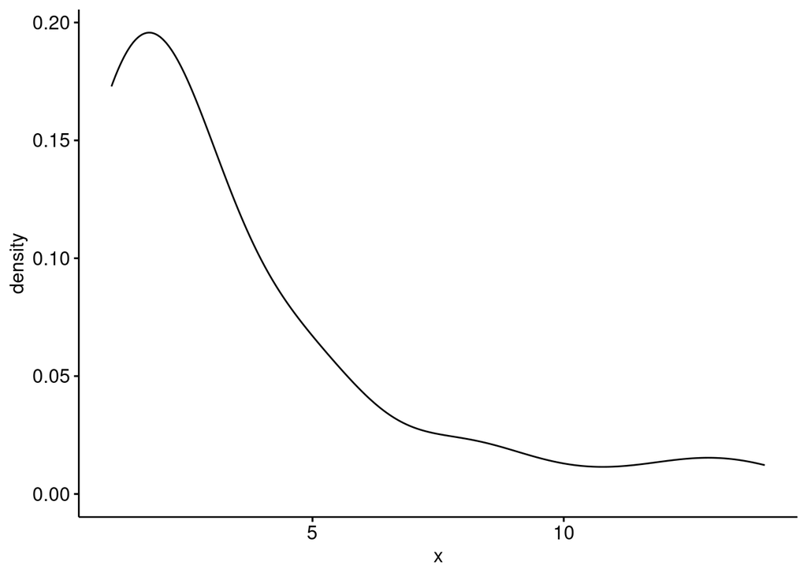

```r
ggdensity(richness_df_NAOMIT$richness)
```

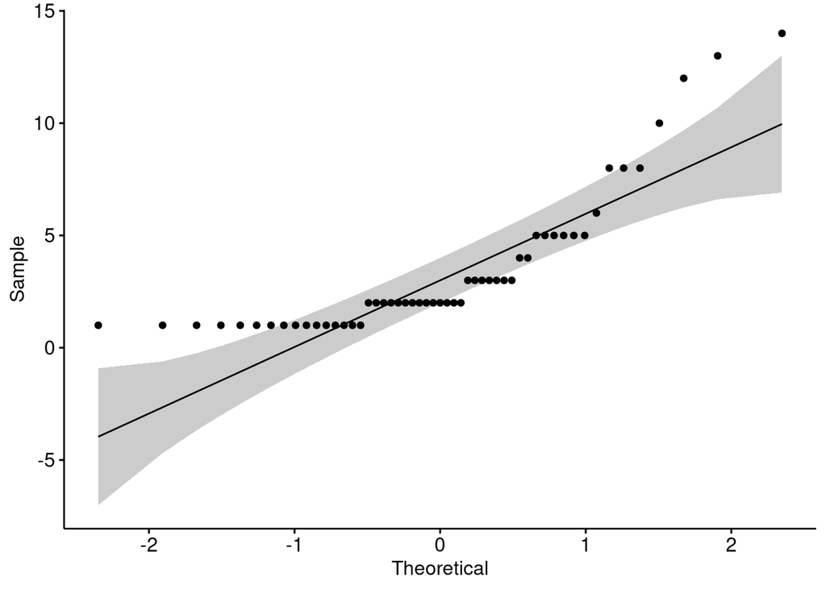

```r
ggqqplot(richness_df_NAOMIT$richness)
```

The results yielded a **Poisson** distribution

Building the model to correct for effects of *sample type*, *school* and *number of sampling event*

```r
richness_sampletype_Poisson_mod_full<-glm(richness~Sample_type+schools+order, data= richness_df_NAOMIT, family = poisson)
summary(richness_sampletype_Poisson_mod_full)
```

```
##
## Call:
## glm(formula = richness ~ Sample_type + schools + order, family = poisson,
##     data = richness_df_NAOMIT)
##
## Coefficients:
##                   Estimate Std. Error z value Pr(>|z|)
## (Intercept)        1.59463    0.23554   6.770 1.29e-11 ***
## Sample_typeswab   -0.37336    0.18121  -2.060  0.03936 *
## Sample_typetissue -0.33325    0.20806  -1.602  0.10923
## schoolsH          -0.48494    0.35403  -1.370  0.17076
## schoolsK           0.02088    0.23450   0.089  0.92905
## schoolsM           0.11296    0.22682   0.498  0.61847
## schoolsR          -1.20522    0.40107  -3.005  0.00266 **
## schoolsW          -0.71876    0.54540  -1.318  0.18756
## order              0.01636    0.03201   0.511  0.60934
## ---
## Signif. codes:  0 '***' 0.001 '**' 0.01 '*' 0.05 '.' 0.1 ' ' 1
##
## (Dispersion parameter for poisson family taken to be 1)
##
##     Null deviance: 122.219  on 52  degrees of freedom
## Residual deviance:  97.381  on 44  degrees of freedom
## AIC: 265.2
##
## Number of Fisher Scoring iterations: 5
```

### Analyzing results for schools

Schools showed a significant effect in the model, so we conduct posthoc tests for pairwise comparisons

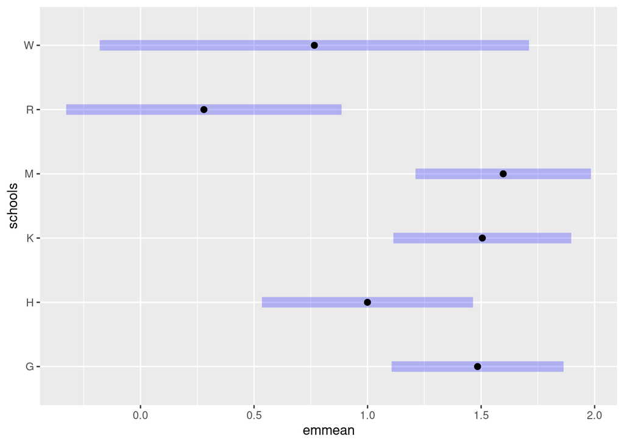

```r
emm_schools_full<-emmeans(richness_sampletype_Poisson_mod_full,~schools)
plot(emm_schools_full)
```

```r
pairs(emm_schools_full, adjust='tukey')
```

```
##  contrast estimate    SE  df z.ratio p.value
##  G - H      0.4849 0.354 Inf   1.370  0.7453
##  G - K     -0.0209 0.235 Inf  -0.089  1.0000
##  G - M     -0.1130 0.227 Inf  -0.498  0.9963
##  G - R      1.2052 0.401 Inf   3.005  0.0318
##  G - W      0.7188 0.545 Inf   1.318  0.7753
##  H - K     -0.5058 0.359 Inf  -1.409  0.7218
##  H - M     -0.5979 0.378 Inf  -1.583  0.6101
##  H - R      0.7203 0.328 Inf   2.197  0.2388
##  H - W      0.2338 0.480 Inf   0.487  0.9966
##  K - M     -0.0921 0.231 Inf  -0.398  0.9987
##  K - R      1.2261 0.405 Inf   3.030  0.0294
##  K - W      0.7396 0.549 Inf   1.347  0.7584
##  M - R      1.3182 0.414 Inf   3.184  0.0182
##  M - W      0.8317 0.568 Inf   1.465  0.6869
##  R - W     -0.4865 0.535 Inf  -0.909  0.9443
##
## Results are averaged over the levels of: Sample_type
## Results are given on the log (not the response) scale.
## P value adjustment: tukey method for comparing a family of 6 estimates
```

Then plotting results from emm_schools_full converted df

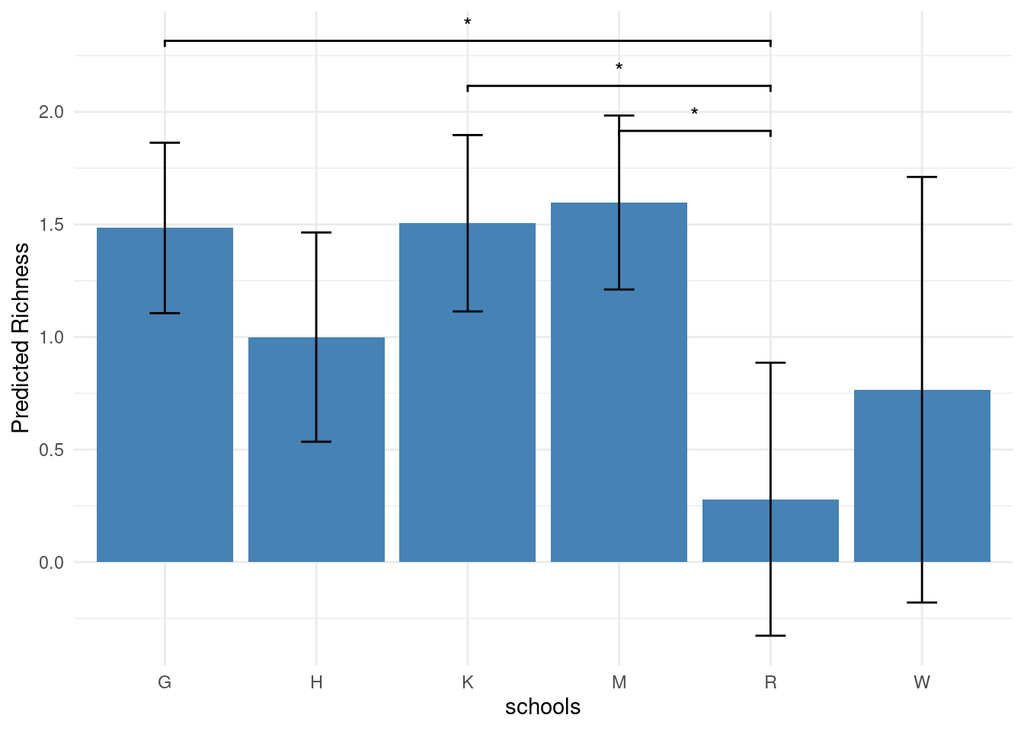

### Analyzing results for sample types

Sample type salso returned a significant effect, so we conducted pairwise comparison

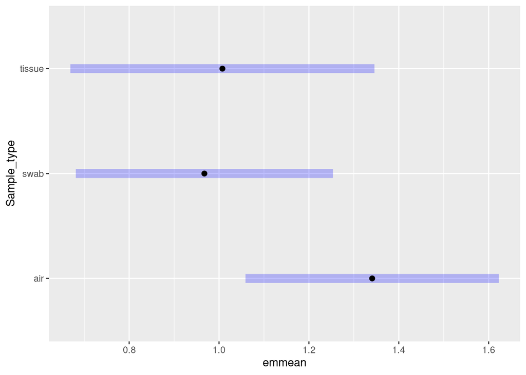

```r
emm_sample_full<-emmeans(richness_sampletype_Poisson_mod_full,~Sample_type)
plot(emm_sample_full)
```

```r
pairs(emm_sample_full, adjust='tukey')
```

```
##  contrast      estimate    SE  df z.ratio p.value
##  air - swab      0.3734 0.181 Inf   2.060  0.0982
##  air - tissue    0.3332 0.208 Inf   1.602  0.2449
##  swab - tissue  -0.0401 0.194 Inf  -0.207  0.9767
##
## Results are averaged over the levels of: schools
## Results are given on the log (not the response) scale.
## P value adjustment: tukey method for comparing a family of 3 estimates
```

The more rigorous tukey test found no significant difference between pairs, with only a slight trend between air and swab samples.

**Sample types therefore did not differ in viral richness** when corrected for effect of school and sampling event

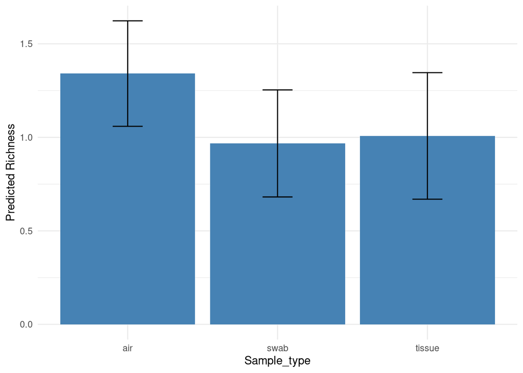